# Week 08 - Agent-based modeling

- Show All Code
- Hide All Code

Simulating macro behavior from micro rules

# What are ABMs?

Agent-Based Models (ABMs) are computational simulations, in which **individual actors (agents)** interact with each other and their environment according to specified rules. The goal of ABMs is to understand how **macro-level phenomena** emerge from **micro-level interactions**.

Especially in the field of analytical sociology (mechanism based explaining), ABMs have emerged as a central tool Bruch and Atwell (2015).

ABMs can help making precise and formalizing theories, by making assumptions explicit and by allowing to test the implications of these assumptions. ABMs can also be used to explore the consequences of different assumptions, and to identify which assumptions are most important for explaining a given phenomenon.

An ABM typically consists of the following components:

1. **Agents**: These are the individual actors in the model, which can represent people, organizations, or other entities. Agents have attributes (e.g., age, income) and behaviors (e.g., decision rules, interactions with other agents).
2. **Environment**: This is the context in which the agents operate, which can be a physical space (e.g., a grid) or a social network. The environment can also have its own dynamics (e.g., changes in resources, policies).
3. **Rules**: These are the decision rules that govern how agents interact with each other and with the environment. Rules can be simple (e.g., “move to a new location if unhappy”) or complex (e.g., “form a social tie with another agent if they have similar opinions”)

We will have a closer look at how ABMs work, by recreating Schellings Social Segregation Model (Schelling 1971).

# Schelling’s Social Segregation Model

```r
library(needs)
needs(tidyverse,
      gridExtra)
```

The Schelling model of segregation, formulated by Thomas Schelling (1921–2016), who received the Nobel Prize in 2005, is an agent-based framework illustrating how even slight preferences for one’s social group can drive significant societal segregation.

This model delves into neighborhood segregation driven by socio-economic factors. While slight differences might exist within each neighborhood, substantial disparities emerge between neighborhoods, curtailing inter-area interactions. Income inequalities often underlie this segregation, propelling affluent individuals toward luxury renovated neighborhoods (gentrification) or suburban locales (suburbanization) in pursuit of specific community compositions.

The Schelling model is pertinent for studying social dynamics where individual actions hinge on others’ behavior, yielding self-reinforcing trends.

Additionally, the model showcases a thought experiment highlighting that segregation can arise without explicit preferences for homogeneous neighborhoods. The key assumptions are that individuals aim to avoid minority status in their neighborhood and neighborhoods necessitate at least a 50:50 resident ratio, prompting migration if unmet.

In essence, the Schelling model underscores how seemingly minor individual preferences can unintentionally yield substantial social segregation. It provides insightful perspectives on comprehending how intricate social dynamics mold neighborhoods, offering a framework to scrutinize unintended effects of social actions.

## Initialization

The original model is depicted on a $N x N$ grid, where each cell can be in one of the three states: uninhabited, inhabited by a member of group 1, or inhabited by a member of group 2. This can also be represented in a matrix, with each element being either 0,1, or 2.

```r
world_size   = 10          # the grid will be 10x10
world_empty  = 0.2         # 20% of the vertices are empty
pop_shares   = c(0.5, 0.5) # two groups with equal sizes
```

The code above sets the parameters of our model. We start with just a few components:

1. `world_size` determines the dimensions of the grid (10x10 in this case).
2. `world_empty` specifies the proportion of unoccupied cells in the grid (20%)
3. `pop_shares` defines two things: the amount of types of agents, that we have and their relative shares.

To ensure reproducibility, we set a seed for the random number generator. This allows us to generate the same random numbers each time we run the code, which is crucial for debugging and sharing results.

```r
set.seed(123)
```

For clean documentation, we can bundle these information into a single list, which we can easily pass to functions later on. This also allows us to keep track of the parameters we used for each simulation run.

```r
params <- list(
  world_size = 25,
  world_empty = 0.1,
  pop_shares = c(0.5, 0.5),
  seed = 123
)
```

When we have these parameters, we can **initialize the world**.

```r
cells <- params$world_size^2
occupied <- floor((1 - params$world_empty) * cells)

group_vector <- c(
  rep(0, cells - occupied),
  rep(1, floor(occupied * params$pop_shares[1])),
  rep(2, floor(occupied * params$pop_shares[2]))
)

set.seed(params$seed)

grid <- matrix(
  sample(group_vector, cells, replace = FALSE),
  nrow = params$world_size,
  ncol = params$world_size
)
```

[figure not shown]

### Preference threshold

In the next step, we define the ‘alike preference’, the threshold or tolerance level that an agent has for being surrounded by neighbors who are similar to them. This preference determines whether an agent considers its current neighborhood as “acceptable” or “unacceptable” based on the proportion of neighbors that belong to the same group as the agent. By adjusting the “alike preference” parameter, you can control the degree of tolerance an agent has for living in a mixed or segregated neighborhood. A higher “alike preference” means that agents are more particular about living near similar neighbors, which can lead to more segregation. On the other hand, a lower “alike preference” allows for greater diversity in the neighborhood.

```r
params$iterations <- 30
params$alike_preference <- 0.3
```

Lastly we define a function that takes a set of xy-coordinates as a vector and identifies the neighbors of a given patch using a *Moore neighborhood* (consisting of the 8 surrounding patches of a cell). The coordinates are adjusted to handle boundaries effectively.

```r
get_neighbors <- function(coords) {

  offsets <- matrix(c(
     1, 0,
     1, 1,
     0, 1,
    -1, 1,
    -1, 0,
    -1,-1,
     0,-1,
     1,-1
  ), ncol = 2, byrow = TRUE)

  n <- sweep(offsets, 2, coords, "+")

  # torus wrapping
  n[n < 1] <- params$world_size
  n[n > params$world_size] <- 1

  n
}
```

Then we need a dataframe to store the results of our simulation, which we can use for analysis and visualization later on.

```r
results <- data.frame(
  iteration = 1:params$iterations,
  happy = rep(NA_real_, params$iterations),
  unhappy = rep(NA_real_, params$iterations)
)
```

### Simulation

Overall happiness is calculated by dividing the count of happy cells by total occupied cells. This value is added to the happiness tracker.

```r
is_happy <- function(x, y, grid, pref) {

  group <- grid[x, y]
  if (group == 0) return(NA)   # empty cell

  neigh <- get_neighbors(c(x, y))
  neigh_vals <- apply(neigh, 1, \(p) grid[p[1], p[2]])

  neigh_vals <- neigh_vals[neigh_vals != 0]  # ignore empty cells
  if (length(neigh_vals) == 0) return(TRUE)

  alike_share <- mean(neigh_vals == group)
  alike_share >= pref
}
```

To neatly visualize this, we can write a plotting function:

```r
plot_grid <- function(grid, iter) {

  df <- expand.grid(
    x = 1:nrow(grid),
    y = 1:ncol(grid)
  )

  df$group <- as.vector(grid)

  ggplot(df, aes(x = x, y = y, fill = factor(group))) +
    geom_tile(color = "grey80") +
    scale_fill_manual(values = c(
      "0" = "white",
      "1" = "pink",
      "2" = "lightblue"
    )) +
    coord_equal() +
    scale_y_reverse() +
    labs(title = paste("Iteration", iter), fill = "") +
    theme_void() +
    theme(plot.title = element_text(hjust = 0.5))
}

plot_happiness <- function(results) {

  plot_data <- pivot_longer(
    results,
    cols = c(happy, unhappy),
    names_to = "state",
    values_to = "share"
  )

  ggplot(plot_data,
         aes(iteration, share, color = state)) +
    geom_line(linewidth = 1.2, na.rm = TRUE) +
    scale_x_continuous(
      limits = c(1, params$iterations),
      breaks = seq(0, params$iterations, by = 20)
    ) +
    scale_y_continuous(
      limits = c(0,1)
    ) +
    labs(
      x = "Time",
      y = "Share of agents",
      color = ""
    ) +
    theme_minimal(base_size = 13)
}
```

```r
dev.new(width = 10, height = 5)

dir.create("Graphics/frames", recursive = TRUE, showWarnings = FALSE)
unlink("Graphics/frames/*.png")

for (t in 1:params$iterations) {

  ## --- find unhappy agents ---
  unhappy <- list()

  for (i in 1:params$world_size) {
    for (j in 1:params$world_size) {

      if (grid[i, j] != 0) {
        if (!is_happy(i, j, grid, params$alike_preference)) {
          unhappy[[length(unhappy) + 1]] <- c(i, j)
        }
      }
    }
  }

  ## --- empty cells ---
  empty_cells <- which(grid == 0, arr.ind = TRUE)

  ## --- move agents ---
  if (length(unhappy) > 0 && nrow(empty_cells) > 0) {

    move_order <- sample(seq_along(unhappy))

    for (k in move_order) {

      if (nrow(empty_cells) == 0) break

      old <- unhappy[[k]]
      new_id <- sample(1:nrow(empty_cells), 1)
      new <- empty_cells[new_id, ]

      grid[new[1], new[2]] <- grid[old[1], old[2]]
      grid[old[1], old[2]] <- 0

      empty_cells[new_id, ] <- old
    }
  }

  ## --- compute happiness shares ---
  agents <- which(grid != 0, arr.ind = TRUE)

  happy_vec <- apply(
    agents,
    1,
    \(pos) is_happy(pos[1], pos[2], grid, params$alike_preference)
  )

  happy_share <- mean(happy_vec)
  unhappy_share <- 1 - happy_share

  results$happy[t] <- happy_share
  results$unhappy[t] <- unhappy_share


  #----------- update plot

  p1 <- plot_grid(grid, t)
  p2 <- plot_happiness(results)

combined_plot <- grid.arrange(p1, p2, ncol = 2)

ggsave(
  filename = paste0("Graphics/frames/frame_", sprintf("%03d", t), ".png"),
  plot = combined_plot,
  width = 10,
  height = 5
)


}
```

To make the dynamics easier to see, we can also save the grid states and turn them into a small animation. I keep this in a separate chunk, because GIF creation can take a bit longer depending on your machine.

```r
needs(magick)

library(magick)

frames <- image_read(
  list.files("Graphics/frames", pattern = "*.png", full.names = TRUE)
)

animation <- image_animate(frames, fps = 5)

image_write(animation, "Graphics/schelling_simulation.gif")
```

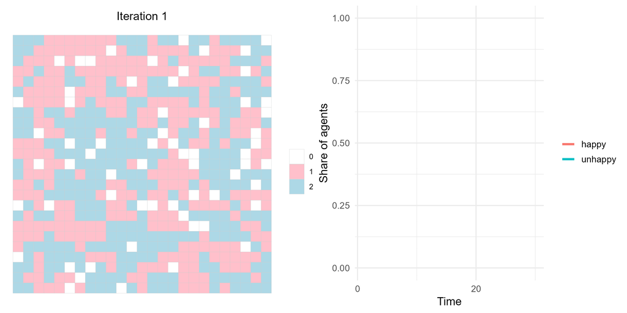

Congratulations! This is your first ABM!

Now think about our model:

1. On which parameters does the behavior of this Schelling model depend?
2. How do the different parameters affect the strength of the observed segregation in the simulated population?
3. Play with the different parameters of the model. Do the results correspond to your expectations from question 2?

## Replication

To check whether the simulation results are stable across repeated runs, we replicate the model several times with the same parameter values. Since the initial grid and the movement of agents include randomness, single runs may differ slightly. By comparing the individual runs with the average trend and the minimum–maximum range, we can see how consistent the overall pattern is.

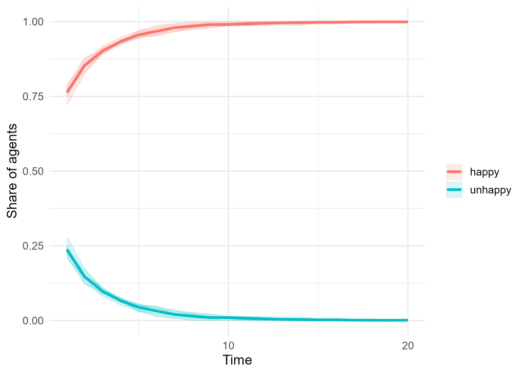

Average dynamics of runs. Individual runs are shown as faint lines in the background. The shaded area shows the minimum–maximum range across runs.

```r
params <- list(
  world_size = 25,
  world_empty = 0.1,
  pop_shares = c(0.5, 0.5),
  seed = 123,
  iterations = 20,
  alike_preference = 0.5,
  runs = 10
)

get_neighbors <- function(coords, world_size) {
  offsets <- matrix(c(
     1, 0,
     1, 1,
     0, 1,
    -1, 1,
    -1, 0,
    -1,-1,
     0,-1,
     1,-1
  ), ncol = 2, byrow = TRUE)

  n <- sweep(offsets, 2, coords, "+")

  # torus wrapping
  n[n < 1] <- world_size
  n[n > world_size] <- 1

  n
}

is_happy <- function(x, y, grid, pref) {
  group <- grid[x, y]

  if (group == 0) return(NA)

  neigh <- get_neighbors(c(x, y), nrow(grid))
  neigh_vals <- apply(neigh, 1, \(p) grid[p[1], p[2]])
  neigh_vals <- neigh_vals[neigh_vals != 0]

  if (length(neigh_vals) == 0) return(TRUE)

  alike_share <- mean(neigh_vals == group)
  alike_share >= pref
}

initialize_grid <- function(params, seed = NULL) {

  if (!is.null(seed)) set.seed(seed)

  cells <- params$world_size^2
  occupied <- floor((1 - params$world_empty) * cells)

  group_vector <- c(
    rep(0, cells - occupied),
    rep(1, floor(occupied * params$pop_shares[1])),
    rep(2, occupied - floor(occupied * params$pop_shares[1]))
  )

  matrix(
    sample(group_vector, cells, replace = FALSE),
    nrow = params$world_size,
    ncol = params$world_size
  )
}

move_unhappy_agents <- function(grid, pref) {

  unhappy <- list()

  for (i in 1:nrow(grid)) {
    for (j in 1:ncol(grid)) {
      if (grid[i, j] != 0 && !is_happy(i, j, grid, pref)) {
        unhappy[[length(unhappy) + 1]] <- c(i, j)
      }
    }
  }

  empty_cells <- which(grid == 0, arr.ind = TRUE)

  if (length(unhappy) > 0 && nrow(empty_cells) > 0) {

    move_order <- sample(seq_along(unhappy))

    for (k in move_order) {

      if (nrow(empty_cells) == 0) break

      old <- unhappy[[k]]
      new_id <- sample(1:nrow(empty_cells), 1)
      new <- empty_cells[new_id, ]

      grid[new[1], new[2]] <- grid[old[1], old[2]]
      grid[old[1], old[2]] <- 0

      empty_cells[new_id, ] <- old
    }
  }

  grid
}

measure_happiness <- function(grid, pref) {

  agents <- which(grid != 0, arr.ind = TRUE)

  happy_vec <- apply(
    agents,
    1,
    \(pos) is_happy(pos[1], pos[2], grid, pref)
  )

  mean(happy_vec)
}

run_schelling <- function(params) {

  run_results <- vector("list", params$runs)

  for (r in 1:params$runs) {

    grid <- initialize_grid(params, seed = params$seed + r)

    results <- data.frame(
      run = r,
      iteration = 1:params$iterations,
      happy = NA_real_,
      unhappy = NA_real_
    )

    for (t in 1:params$iterations) {

      grid <- move_unhappy_agents(grid, params$alike_preference)

      happy_share <- measure_happiness(grid, params$alike_preference)

      results$happy[t] <- happy_share
      results$unhappy[t] <- 1 - happy_share
    }

    run_results[[r]] <- results
  }

  bind_rows(run_results)
}

replication_results <- run_schelling(params)

replication_long <- replication_results |>
  pivot_longer(
    cols = c(happy, unhappy),
    names_to = "state",
    values_to = "share"
  )

replication_summary <- replication_long |>
  group_by(iteration, state) |>
  summarise(
    min = min(share),
    mean = mean(share),
    max = max(share),
    .groups = "drop"
  )

p_replication <- ggplot() +
  geom_line(
    data = replication_long,
    aes(
      x = iteration,
      y = share,
      group = interaction(run, state),
      color = state
    ),
    alpha = 0.15,
    linewidth = 0.6
  ) +
  geom_ribbon(
    data = replication_summary,
    aes(
      x = iteration,
      ymin = min,
      ymax = max,
      fill = state
    ),
    alpha = 0.15
  ) +
  geom_line(
    data = replication_summary,
    aes(
      x = iteration,
      y = mean,
      color = state
    ),
    linewidth = 1.2
  ) +
  scale_x_continuous(
    limits = c(1, params$iterations),
    breaks = seq(0, params$iterations, by = 10)
  ) +
  scale_y_continuous(limits = c(0, 1)) +
  labs(
    x = "Time",
    y = "Share of agents",
    color = "",
    fill = ""
  ) +
  theme_minimal(base_size = 13)

p_replication
```

This allows us to see whether the model produces a similar pattern each time it is run. If the individual lines stay close together and the min–max band is narrow, the results are relatively stable. If the lines differ strongly and the band is wide, the outcome depends more strongly on the random initialization and movement process.

## Variations

The function above makes it easy to compare different versions of the model. One especially important parameter is the preference threshold. If the threshold is low, agents are satisfied with more mixed neighborhoods. If the threshold is high, agents need more similar neighbors to stay where they are.

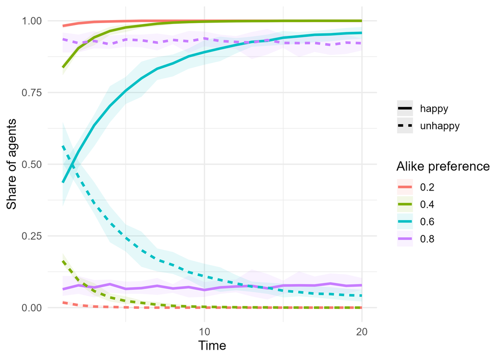

```r
preference_values <- c(0.2, 0.4, 0.6, 0.8)

preference_results <- map_dfr(preference_values, function(pref) {

  scenario_params <- params
  scenario_params$alike_preference <- pref

  run_schelling(scenario_params) |>
    mutate(alike_preference = pref)
})

preference_long <- preference_results |>
  pivot_longer(
    cols = c(happy, unhappy),
    names_to = "state",
    values_to = "share"
  )

preference_summary <- preference_long |>
  group_by(alike_preference, iteration, state) |>
  summarise(
    min = min(share),
    mean = mean(share),
    max = max(share),
    .groups = "drop"
  )

p_variation <- ggplot(
  preference_summary,
  aes(
    x = iteration,
    y = mean,
    color = factor(alike_preference),
    fill = factor(alike_preference),
    linetype = state,
    group = interaction(alike_preference, state)
  )
) +
  geom_ribbon(
    aes(ymin = min, ymax = max),
    alpha = 0.08,
    color = NA
  ) +
  geom_line(linewidth = 1.2) +
  scale_x_continuous(
    limits = c(1, params$iterations),
    breaks = seq(0, params$iterations, by = 10)
  ) +
  scale_y_continuous(limits = c(0, 1)) +
  labs(
    x = "Time",
    y = "Share of agents",
    color = "Alike preference",
    fill = "Alike preference",
    linetype = ""
  ) +
  theme_minimal(base_size = 13)

p_variation
```

This plot shows how strongly the model reacts to changes in individual homophily preference In many runs, even moderate preferences can produce strong macro-level sorting. This is exactly the central point of the Schelling model: segregation can emerge even when agents do not explicitly prefer complete segregation.

# Limitations of ABMs

ABMs can yield generative sufficiency: they can show that a proposed mechanism is able to generate an observed macro pattern. In our case, the Schelling model shows that individual preferences about neighbors can generate segregation at the population level.

However, ABMs are not a silver bullet for social science research. Some of the main limitations include:

1. **They do not prove that the mechanism is true.** If a model generates a realistic pattern, this only means that the mechanism could be one explanation. Other mechanisms might produce the same pattern.
2. **They depend strongly on assumptions.** Small changes in rules, parameters, or model structure can lead to different outcomes.
3. **They can be difficult to validate empirically.** It is often hard to show that the decision rules in the model really match how people behave in the real world.
4. **They simplify social reality.** This is useful for theory building, but it also means that many relevant factors are left out.
5. **They can look more precise than they are.** A colorful simulation can be persuasive, but the output is only as good as the assumptions behind it.

The strength of ABMs is therefore not that they give final answers. Their strength is that they force us to be explicit: Who are the actors? What do they want? How do they interact? And how can small-scale behavior generate large-scale social patterns?

What are the limitations of this model? Which real-world factors are not included in the model, but might be relevant for understanding segregation in real cities?

# ABMS in CSS

The Schelling modle is only one example for the application of ABMs in the social sciences.

Some important types of ABMs are:

- **Diffusion models**
  - These models study how information, innovations, opinions, diseases, or behaviors spread through a population.
  - Agents may adopt something once enough of their neighbors have already adopted it.
  - Examples include the spread of rumors, political opinions, protest behavior, technologies, or health behavior.
- **Threshold models**
  - Threshold models are closely related to diffusion models.
  - The basic idea is that agents act only when a certain number or share of others has already acted.
  - A famous example is **Granovetter’s threshold model of collective behavior**.
  - In this model, some people may join a protest immediately, while others only join if many others have already joined.
  - The important insight is that small differences in individual thresholds can create very different collective outcomes.
- **Network-based ABMs**
  - In network ABMs, agents do not interact with everyone equally.
  - Instead, they interact through a social network.
  - This makes it possible to study how network structure affects social outcomes.
  - For example, information may spread quickly in highly connected networks, while clustered networks may produce stronger local agreement.
  - Network ABMs are often used to study social influence, polarization, friendship formation, contagion, and cooperation.
- **Opinion dynamics models**
  - These models study how people change their opinions through interaction.
  - In some models, agents become more similar when they interact.
  - In others, agents only listen to people whose opinions are already close to their own.
  - These models can help explain why societies sometimes reach consensus, while in other cases they become polarized.
- **Cultural dissemination models**
  - A famous example is **Axelrod’s model of cultural dissemination**.
  - In this model, agents are more likely to interact if they are already culturally similar.
  - Through interaction, they become even more similar.
  - The model shows how local similarity can increase while global diversity remains.
  - This means that neighboring agents may become similar, but the whole population can still remain divided into different cultural regions.
- **Cooperation and norm models**
  - These models study when agents cooperate, defect, punish, imitate, or follow norms.
  - They are often connected to game theory, for example the prisoner’s dilemma.
  - ABMs make it possible to add repeated interaction, learning, spatial structure, or social networks.
  - This helps researchers study when cooperation or social norms become stable.
  - https://ncase.me/trust/
- **Resource and inequality models**
  - A classic example is **Sugarscape**, developed by Epstein and Axtell.
  - In this model, agents move through an artificial landscape and collect resources.
  - Although the rules are simple, the model can produce patterns related to inequality, migration, trade, wealth accumulation, and survival.
  - It is often used to show how complex social structures can emerge from simple behavioral rules.

Overall, agent-based models are useful because they allow us to connect individual behavior with collective outcomes. Models such as Schelling’s segregation model, Granovetter’s threshold model, Axelrod’s cultural dissemination model, and Sugarscape all show that social patterns do not always require centralized coordination. Instead, they can emerge from many local interactions between agents.

## References

Bianchi, Federico, and Flaminio Squazzoni. 2015. “Agent-Based Models in Sociology.” *WIREs Computational Statistics* 7 (4): 284–306. https://doi.org/10.1002/wics.1356.

Bruch, Elizabeth, and Jon Atwell. 2015. “Agent-Based Models in Empirical Social Research.” *Sociological Methods & Research* 44 (2): 186–221. https://doi.org/10.1177/0049124113506405.

Jarvis, Benjamin F., Marc Keuschnigg, and Peter Hedström. 2021. “Analytical Sociology Amidst a Computational Social Science Revolution.” In *Handbook of Computational Social Science, Volume 1*, 1st ed., 33–52. London: Routledge. https://doi.org/10.4324/9781003024583-4.

Schelling, Thomas C. 1971. “Dynamic Models of Segregation.” *The Journal of Mathematical Sociology* 1 (2): 143–86. https://doi.org/10.1080/0022250X.1971.9989794.

## Copyright

© 2026 Leonie Steinbrinker